# Homework 03

Author

Tasmiah Khan

## Loading in data

```r
library(tidyverse)
pubmed <- read_csv("~/Downloads/pubmed.csv")
pubmed
```

```
# A tibble: 3,241 × 2
   abstract                                                                term
   <chr>                                                                   <chr>
 1 "Background and aims: Many patients with coronavirus disease 2019 (COV… covid
 2 "Introduction: Contradictory data have been reported on the incidence … covid
 3 "This article aims at collecting all information needed for dentists r… covid
 4 "OBJECTIVE. The objective of our study was to determine the misdiagnos… covid
 5 "Background: Much of the focus regarding the global pandemic of corona… covid
 6 "The World Health Organization (WHO) has issued a warning that, althou… covid
 7 "The coronavirus disease (COVID-19) has spread all around the world in… covid
 8 "Objective: The novel severe acute respiratory syndrome coronavirus 2 … covid
 9 "COVID-19 has been declared a global pandemic by the World Health Orga… covid
10 "Background: Coronavirus disease 2019 (COVID-19) is a novel infectious… covid
# ℹ 3,231 more rows
```

# Text Mining

## Question 1

```r
library(tidytext)
library(dplyr)
pubmed |> group_by(term) |> count(term, name="# of abstracts")
```

```
# A tibble: 5 × 2
# Groups:   term [5]
  term            `# of abstracts`
  <chr>                      <int>
1 covid                        981
2 cystic fibrosis              376
3 meningitis                   317
4 preeclampsia                 780
5 prostate cancer              787
```

```r
token_counts <- pubmed |>
  unnest_tokens(token, abstract) |> group_by(term) |>
  count(token, sort = TRUE)
token_counts
```

```
# A tibble: 39,240 × 3
# Groups:   term [5]
   term            token     n
   <chr>           <chr> <int>
 1 covid           the    9741
 2 covid           of     7668
 3 covid           covid  7275
 4 preeclampsia    the    7119
 5 covid           19     7035
 6 covid           and    6861
 7 preeclampsia    of     6837
 8 prostate cancer the    6100
 9 prostate cancer of     5682
10 preeclampsia    and    5255
# ℹ 39,230 more rows
```

```r
top_five_tokens <- token_counts |>
  group_by(term) |>
  slice_max(order_by = n, n = 5, with_ties = FALSE) |>
  arrange(term, desc(n)) |>
  ungroup()
top_five_tokens
```

```
# A tibble: 25 × 3
   term            token     n
   <chr>           <chr> <int>
 1 covid           the    9741
 2 covid           of     7668
 3 covid           covid  7275
 4 covid           19     7035
 5 covid           and    6861
 6 cystic fibrosis the    2677
 7 cystic fibrosis of     2304
 8 cystic fibrosis and    1777
 9 cystic fibrosis in     1497
10 cystic fibrosis to     1011
# ℹ 15 more rows
```

There are 981 abstacts for the term covid, 376 abstracts for the term cystic fibrosis, 317 abstracts for the term meningitis, 780 abstracts for the term preeclampsia, and 787 abstracts for the term prostrate cancer.

After tokenizing the abstracts and counting the number of each token from highest to lowest, I did not find any token terms that were interesting in the first 10 displayed rows for terms of covid, preeclampsia, and prostate cancer. Most of the terms seem to be filler words in a sentence and don’t have a meaningful explanation to what the abstract will be about. When I look at the last 10 rows, I find that these tokens appear less often but seem to be more informative to what the abstract will be about especially for terms of covid, meningitis, preeclampsia, and prostrate cancer.

The 5 most common tokens for the search term covid include “the, of, covid, 19, and”. For the search term cystic fibrosis and preeclampsia, the most common 5 tokens include “the, of, and, in, to.” The 5 most common tokens in the search term meningitis include “the, of, and, in, a.” For prostate cancer, the 5 most common tokens are “the, of, and, prostrate, cancer.”

## Question 2

```r
stop_words |>
  filter(lexicon == "snowball") |>
  pull(word)
```

```
  [1] "i"          "me"         "my"         "myself"     "we"
  [6] "our"        "ours"       "ourselves"  "you"        "your"
 [11] "yours"      "yourself"   "yourselves" "he"         "him"
 [16] "his"        "himself"    "she"        "her"        "hers"
 [21] "herself"    "it"         "its"        "itself"     "they"
 [26] "them"       "their"      "theirs"     "themselves" "what"
 [31] "which"      "who"        "whom"       "this"       "that"
 [36] "these"      "those"      "am"         "is"         "are"
 [41] "was"        "were"       "be"         "been"       "being"
 [46] "have"       "has"        "had"        "having"     "do"
 [51] "does"       "did"        "doing"      "would"      "should"
 [56] "could"      "ought"      "i'm"        "you're"     "he's"
 [61] "she's"      "it's"       "we're"      "they're"    "i've"
 [66] "you've"     "we've"      "they've"    "i'd"        "you'd"
 [71] "he'd"       "she'd"      "we'd"       "they'd"     "i'll"
```

[output cut: 20 more lines]

```r
pubmed_stop <- pubmed |>
  unnest_tokens(token, abstract) |>
   group_by(term) |>
  anti_join(stop_words, by = c("token" = "word")) |>
  count(token, sort = TRUE)
pubmed_stop
```

```
# A tibble: 36,863 × 3
# Groups:   term [5]
   term            token            n
   <chr>           <chr>        <int>
 1 covid           covid         7275
 2 covid           19            7035
 3 prostate cancer cancer        3840
 4 prostate cancer prostate      3832
 5 covid           patients      2293
 6 preeclampsia    pre           2038
 7 preeclampsia    eclampsia     2005
 8 preeclampsia    preeclampsia  1863
 9 preeclampsia    women         1196
10 preeclampsia    pregnancy      969
# ℹ 36,853 more rows
```

```r
top_five_tokens_stop <- pubmed_stop |>
  group_by(term) |>
  slice_max(order_by = n, n = 5, with_ties = FALSE) |>
  arrange(term, desc(n)) |>
  ungroup()
top_five_tokens_stop
```

```
# A tibble: 25 × 3
   term            token        n
   <chr>           <chr>    <int>
 1 covid           covid     7275
 2 covid           19        7035
 3 covid           patients  2293
 4 covid           disease    943
 5 covid           pandemic   800
 6 cystic fibrosis fibrosis   867
 7 cystic fibrosis cystic     862
 8 cystic fibrosis cf         625
 9 cystic fibrosis patients   586
10 cystic fibrosis disease    400
# ℹ 15 more rows
```

After removing stop words from the pubmed dataset, the top 10 most tokens that appear across all the search terms are “covid, 19, cancer, prostate,patients, pre, eclampsia, preeclampsia, women, and pregnancy.” Without stop words, the top 10 most tokens that appeared were “the, of, covid, the, 19, and, of, the, of, and.”

The top 5 tokens for the search term covid after removing the stop words are “covid, 19, patients, disease, pandemic.” For cystic fibrosis, the top 5 tokens are “fibrosis, cystic, cf, patients, disease” after removing stop words. The top 5 tokens of th term meningitis after removing stop words are “patients, meningitis, meningeal, csf, clinical.” Preeclampsia had the top 5 tokens after removing stop words, which include “pre, eclampsia, preeclampsia, women, pregnancy.” The term prostrate cancer had the top 5 most tokens as “cancer, prostate, patients, treatment, disease” after removing stop words.

## Question 3

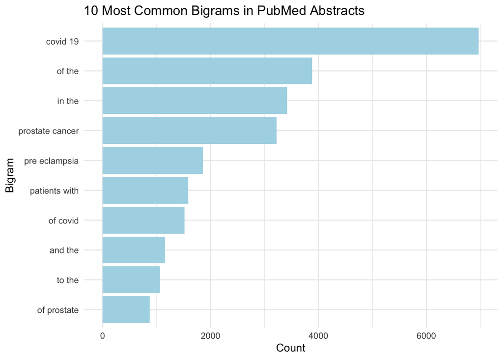

```r
pubmed |>
  unnest_tokens(
    ngram,
    abstract,
    token = "ngrams",
    n = 2
  ) |>
  count(ngram, sort = TRUE) |>
  slice_max(order_by = n, n = 10, with_ties = FALSE) |>
  ggplot(aes(x = n, y = fct_reorder(ngram, n))) +
  geom_col(fill = "lightblue") +
  labs(
    x = "Count",
    y = "Bigram",
    title = "10 Most Common Bigrams in PubMed Abstracts"
  ) +
  theme_minimal()
```

## Question 4

```r
pubmed |>
  unnest_tokens(token, abstract) |>
  count(token, term) |>
  bind_tf_idf(token, term, n) |>
  group_by(term) |>
  slice_max(
    order_by = tf_idf,
    n = 5,
    with_ties = FALSE
  ) |>
  arrange(term, desc(tf_idf)) |>
  ungroup()
```

```
# A tibble: 25 × 6
   token       term                n      tf   idf  tf_idf
   <chr>       <chr>           <int>   <dbl> <dbl>   <dbl>
 1 covid       covid            7275 0.0371  1.61  0.0597
 2 pandemic    covid             800 0.00408 1.61  0.00657
 3 coronavirus covid             647 0.00330 1.61  0.00531
 4 sars        covid             372 0.00190 1.61  0.00305
 5 cov         covid             334 0.00170 1.61  0.00274
 6 cf          cystic fibrosis   625 0.0127  0.916 0.0117
 7 fibrosis    cystic fibrosis   867 0.0176  0.511 0.00901
 8 cystic      cystic fibrosis   862 0.0175  0.511 0.00896
 9 cftr        cystic fibrosis    86 0.00175 1.61  0.00282
10 sweat       cystic fibrosis    83 0.00169 1.61  0.00272
# ℹ 15 more rows
```

For covid search term, the 5 tokens with the highest TF-IDF values are “covid, pandemic, coronavirus, sars, cov” and for cystic fibrosis, the 5 tokens with the highest TF-IDF are “cf, fibrosis, cystic, cftr, sweat.” Meningitis has the top 5 TF-IDF values for tokens: “meningitis, meningeal, pachymeningitis, csf, meninges.” Preeclampsia has the top 5 TF-IDF values for tokens: “eclampsia, preeclampsia, pregnancy, maternal, gestational.” For prostate cancer search term, the 5 tokens with the highest TF-IDF value are “prostate, androgen, psa, prostatectomy, castration.”

Compared to question 1, these top 5 TF-IDF value tokens are more informative than the top 5 tokens that appeared across all the search terms in question 1 because those tokens were filler words. Covid did appear as a token in the search term covid for this question and question 1. Similarly, prostate also appeared as a frequent token in this exercise and in question 1. These differences are attributed to the TF-IDF value since TF measures how frequently a word appears in a single search term or “document,” and IDF measures how rare or common this word appears across all abstracts. A high TF-IDF score indicates that the word does appear frequently in that single abstract but rarely across the rest of the collection of abstracts, making it a signature keyword. This occurs because as we see in Question 1, most common words like “the”, “is”, or “and” appear often among many abstracts and are heavily downweighted while unique words are given more weight. Therefore, this exercises pulls out the top 5 words that don’t appear as often and more meaningful to the search term than filler words that are extremely common.

# Sentiment Analysis

```r
library(textdata)
get_sentiments('nrc')
```

```
# A tibble: 13,872 × 2
   word        sentiment
   <chr>       <chr>
 1 abacus      trust
 2 abandon     fear
 3 abandon     negative
 4 abandon     sadness
 5 abandoned   anger
 6 abandoned   fear
 7 abandoned   negative
 8 abandoned   sadness
 9 abandonment anger
10 abandonment fear
# ℹ 13,862 more rows
```

```r
get_sentiments('afinn')
```

```
# A tibble: 2,477 × 2
   word       value
   <chr>      <dbl>
 1 abandon       -2
 2 abandoned     -2
 3 abandons      -2
 4 abducted      -2
 5 abduction     -2
 6 abductions    -2
 7 abhor         -3
 8 abhorred      -3
 9 abhorrent     -3
10 abhors        -3
# ℹ 2,467 more rows
```

## Question 5

```r
pubmed_nrc <- pubmed |>
  unnest_tokens(token, abstract) |>
  inner_join(
    get_sentiments("nrc"),
    by = c("token" = "word"),
    relationship = "many-to-many"
  )

most_common_sentiment <- pubmed_nrc |>
    count(term, sentiment) |>
    group_by(term) |>
    slice_max(order_by = n, n = 1, with_ties = FALSE)
most_common_sentiment
```

```
# A tibble: 5 × 3
# Groups:   term [5]
  term            sentiment     n
  <chr>           <chr>     <int>
1 covid           positive   9874
2 cystic fibrosis positive   2747
3 meningitis      negative   2109
4 preeclampsia    positive   8014
5 prostate cancer negative   8918
```

```r
sentiment_removed <- pubmed_nrc |>
  filter(!sentiment %in% c("positive", "negative")) |>
  count(term, sentiment) |>
  group_by(term) |>
  slice_max(order_by = n, n = 1, with_ties = FALSE)
sentiment_removed
```

```
# A tibble: 5 × 3
# Groups:   term [5]
  term            sentiment        n
  <chr>           <chr>        <int>
1 covid           fear          7730
2 cystic fibrosis disgust       1714
3 meningitis      fear          1510
4 preeclampsia    anticipation  4780
5 prostate cancer fear          8118
```

Using the NRC lexicon, the most common sentiment for each search term is “positive” or “negative.” The most common sentiment for the search terms covid, cystic fibrosis, preeclampsia is “positive” and the most common sentiment for the search terms meningitis and prostrate cancer is “negative.” If I remove “positive” or “negative” from the NRC list, “fear” shows up as the most common sentiment in the search terms covid, meningitis, and prostate cancer. After removal of the “positive” and “negative” sentiment from the NRC lexicon list, “disgust” is the most common sentiment for the search term cystic fibrosis and “anticipation” is the most common sentiment for the search term preeclampsia.

## Question 6

```r
pubmed_afinn <- pubmed |>
  mutate(abstract_id = row_number()) |>
  unnest_tokens(token, abstract) |>
  inner_join(
    get_sentiments("afinn"),
    by = c("token" = "word")
  ) |>
  group_by(abstract_id, term) |>
  summarise(sentiment = mean(value),
            .groups="drop")

pubmed_afinn
```

```
# A tibble: 3,163 × 3
   abstract_id term  sentiment
         <int> <chr>     <dbl>
 1           1 covid    -1.13
 2           2 covid    -2
 3           3 covid     0.214
 4           4 covid    -0.8
 5           5 covid    -1.67
 6           6 covid    -0.143
 7           7 covid     0.167
 8           8 covid     0.909
 9           9 covid    -0.222
10          10 covid    -1.62
# ℹ 3,153 more rows
```

The average positivity score for each abstract could be negative, indicating more negative language, or they could be positive, indicating more positive language.

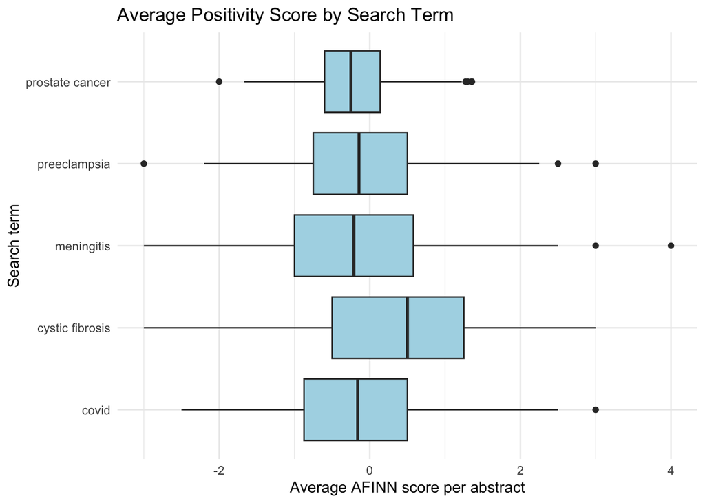

```r
ggplot(pubmed_afinn, aes(x = term, y = sentiment)) +
  geom_boxplot(fill = "lightblue") +
  coord_flip() +
  labs(
    title = "Average Positivity Score by Search Term",
    x = "Search term",
    y = "Average AFINN score per abstract"
  ) +
  theme_minimal()
```

According to the plot, cystic fibrosis has a higher and positive median of abstracts’ average positivity scores compared to other search terms, which demonstrates more positive language. The other search terms have lower medians of the average positivity scores and are negative medians, indicating more negative language. Prostate cancer shows less variability in the abstracts’ average positivity scores whereas cystic fibrosis has greater variability. The distributions of all the search terms overlap, which means that the abstracts from all the search terms have similar average positivity scores.